# Making a Scatter Plot

```python
%matplotlib inline
from ggplot import *
```

### Basics

To make a scatter plot in ggplot, the first thing you'll need is a dataset. ggplot likes pandas DataFrames the best, so it is highly recommended that you load your data into pandas before starting to use ggplot.

We'll use ggplot's built-in `mtcars` dataset for this set of examples.

```python
mtcars.head()
```

|  | name | mpg | cyl | disp | hp | drat | wt | qsec | vs | am | gear | carb |
| --- | --- | --- | --- | --- | --- | --- | --- | --- | --- | --- | --- | --- |
| 0 | Mazda RX4 | 21.0 | 6 | 160.0 | 110 | 3.90 | 2.620 | 16.46 | 0 | 1 | 4 | 4 |
| 1 | Mazda RX4 Wag | 21.0 | 6 | 160.0 | 110 | 3.90 | 2.875 | 17.02 | 0 | 1 | 4 | 4 |
| 2 | Datsun 710 | 22.8 | 4 | 108.0 | 93 | 3.85 | 2.320 | 18.61 | 1 | 1 | 4 | 1 |
| 3 | Hornet 4 Drive | 21.4 | 6 | 258.0 | 110 | 3.08 | 3.215 | 19.44 | 1 | 0 | 3 | 1 |
| 4 | Hornet Sportabout | 18.7 | 8 | 360.0 | 175 | 3.15 | 3.440 | 17.02 | 0 | 0 | 3 | 2 |

#### Simple X/Y Plot

The simplest plot you can make is an x/y plot. To do this in ggplot, first create a base layer using the `ggplot` function. Pass in your data and aesthetics that map columns in your DataFrame to `x` and `y`. In this case, we're going to look at the relationship between car weight (`wt`) and miles per gallon (`mpg`), so we'll set the x value of our aesthetics to `wt` and the y value to `mpg`.

Once the aesthetics are defined, we just need to add a `geom_point` layer to our plot.

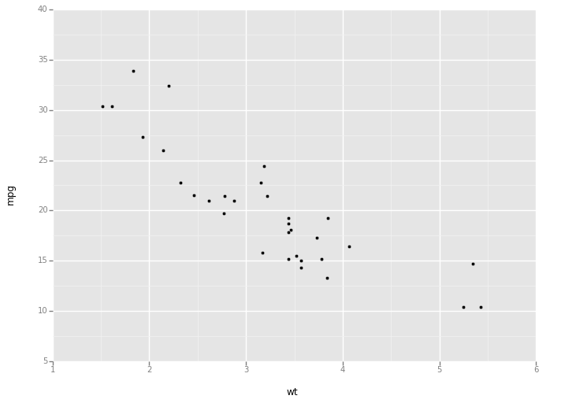

```python
p = ggplot(mtcars, aes(x='wt', y='mpg'))
p + geom_point()
```

#### Controlling other aesthetics

In addition to the x and y variables, you can also control the shape, size, color, alpha (see throughness), and other "aesthetics" of your scatterplot. To do this, just include definitions for the aesthetic you'd like to control. For instance, let's set the color of each point in our graph to the acceleration (`qsec`) of each car.

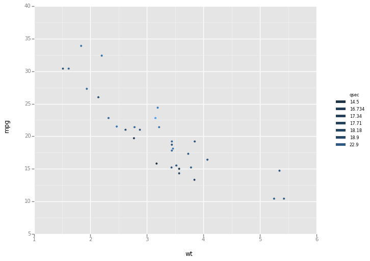

```python
p = ggplot(mtcars, aes(x='wt', y='mpg', color='qsec')) + geom_point()
print(p)
```

#### Discrete Color

Since `qsec` is a continuous variable you probably noticed that you got that nice, graduated legend on the right side of the last plot that indicated the value of each color. If you were to use a discrete variable such as `name` for the color, watch what happens.

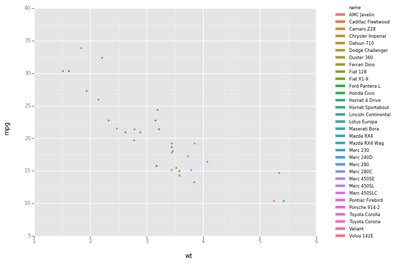

```python
p = ggplot(mtcars, aes(x='wt', y='mpg', color='name')) + geom_point()
p
```

You can also use the ggplot shorthand `factor` to discretize continuous variables. For example, let's change `cyl` from a numerical to a categorical variable.

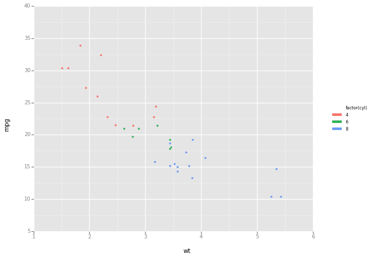

```python
ggplot(mtcars, aes(x='wt', y='mpg', color='factor(cyl)')) + geom_point()
```

#### Pro Tip

Keep in mind that some aesthetics only work for continuous data, some only work for discrete data, and some work for both.

For more on which aesthetics are best in certain situations, read the aesthetics API documentation.